# Regression and Conditional Independence Assumption

## **The National Supported Work (NSW) Experiment**

The National Supported Work (NSW) program was a job training initiative conducted in the mid-1970s in the United States. The program targeted disadvantaged individuals, including the long-term unemployed and individuals with limited labor market experience, and aimed to improve future earnings through subsidized work experience and training.

Eligible participants were randomly assigned either to receive the NSW training program or to a control group that did not receive training. Because assignment to treatment was randomized, the treated and control groups are comparable on average, both in observed and unobserved characteristics.

As a result, simple comparisons of post-program earnings between treated and control individuals in the experimental sample can be interpreted as credible estimates of the causal effect of the training program, without relying on selection-on-observables or other econometric assumptions.

| Variable | Description |
| --- | --- |
| `treat` - treatment variable | Treatment assignment (1 = treated, 0 = control). |
| `age` | Age in years (pre-treatment) |
| `education` | Years of schooling (pre-treatment) |
| `black` | 1 = Black, 0 = otherwise |
| `hispanic` | 1 = Hispanic, 0 = otherwise |
| `married` | 1 = married, 0 = not married |
| `nodegree` | 1 = no high school degree, 0 = with degree |
| `re74` | Income in 1974 (pre-treatment), USD |
| `re75` | Income in 1975 (pre-treatment), USD |
| `re78` - outcome variable | Income in 1978 (post-treatment), USD |

1. Write the causal estimand for the effect of NSW using the Potential Outcomes framework. Clearly define 𝑌1𝑖, 𝑌0𝑖, and the estimand. Is this an ATE or ATT?

   The causal estimand is $△_i$ = $Y_1i$ - $Y_0i$.  
   The estimand is the earnings per individual.  
   $Y_1i$: individual received the NSW training program.  
   $Y_0i$: individual did not receive the NSW training program.  
   This is an ATE since there is random assignment, therefore $Y_1$ and $Y_0$ are independent of each other.
2. Balance table

```r
datasummary_balance(~ treat,
                    fmt = fmt_sprintf("%.3f"),
                    dinm_statistic = "p.value",
                    data = df %>% select(treat, re78),
                    title = "Descriptive Statistics and Balance")
```

Descriptive Statistics and Balance

|  | 0 Mean | 0 Std. Dev. | 1 Mean | 1 Std. Dev. | Diff. in Means | p |
| --- | --- | --- | --- | --- | --- | --- |
| re78 | 4554.801 | 5483.836 | 6349.144 | 7867.402 | 1794.342 | 0.008 |

3. Estimate the average treatment effect of NSW on earnings in 1978 using a difference-in-means estimator.

   Earnings (in 1978) of those who received the NSW training program are higher by $1,794.342 on average. The p-value is .008 and is therefore significant at the .01 level. The assumption here is that the selection was random, so we eliminate the possibility that the individuals would have earned higher regardless of the program.

## **The LaLonde (1986) Study**

LaLonde (1986) compares experimental and non-experimental estimates of the impact of a job training program, the National Supported Work (NSW) program. Because participation in NSW was randomized, the experimental data provide a credible benchmark for the causal effect of training on earnings.

LaLonde then replaces the experimental control group with non-experimental controls drawn from the CPS and estimates the program effect using common econometric methods, including regression adjustment. The idea was to see if our econometric methods could recover the experimental benchmark when we used non-experimental controls instead of the experimental controls.

Balance table

```r
datasummary_balance(~ treat,
                    data = df02 %>% select(treat, re78),
                    fmt = fmt_sprintf("%.3f"),
                    dinm_statistic = "p.value",
                    title = "Descriptive Statistics and Balance")
```

Descriptive Statistics and Balance

|  | 0 Mean | 0 Std. Dev. | 1 Mean | 1 Std. Dev. | Diff. in Means | p |
| --- | --- | --- | --- | --- | --- | --- |
| re78 | 10171.111 | 8851.878 | 6349.144 | 7867.402 | -3821.967 | 0.000 |

1. State the Conditional Independence Assumption (CIA) formally and explain what it means in this setting.

   The Conditional Independence Assumption states that after conditioning on a set of covariates $X_i$, the treatment is as good as randomly assigned. Once the observed characteristics are controlled for, there would be no remaining unobserved factors that affect both the treatment program and the outcome. If CIA holds, then we can estimate the causal effect of the treatment. In this case, conditioning on education, race, age, and marital status, we can assume that assignment into the NSW program is random. The higher earnings received by the participants of the program is due to NSW, and not due to other factors.
2. Regression table

```r
# models
models <- list(
  "1. No controls" = lm(re78 ~ treat, data = df02),
  "2. Demographic controls " = lm(re78 ~ treat + age + education + black + hispanic + married + nodegree, data = df02),
  "3. Full model " = lm(re78 ~ treat + age + education + black + hispanic + married + nodegree + re74 + re75, data = df02)
)

# table
modelsummary(models,
             vcov = "HC1",
             stars = T,
             gof_omit = "[^R2|R2 Adj.|Num.Obs]")
```

|  | 1. No controls | 2. Demographic controls | 3. Full model |
| --- | --- | --- | --- |
| (Intercept) | 10171.111*** | 1761.054 | 3960.029** |
|  | (181.899) | (1547.775) | (1342.799) |
| treat | -3821.967*** | -697.724 | 1172.697+ |
|  | (605.073) | (680.248) | (666.185) |
| age |  | 64.519** | -94.993*** |
|  |  | (19.742) | (16.451) |
| education |  | 494.070*** | 295.771** |
|  |  | (104.163) | (89.927) |
| black |  | -1948.766*** | -1089.949* |
|  |  | (503.880) | (429.716) |
| hispanic |  | -390.978 | 420.584 |
|  |  | (610.613) | (534.249) |
| married |  | 3462.489*** | -13.047 |
|  |  | (426.090) | (367.398) |
| nodegree |  | -677.823 | 397.166 |
|  |  | (512.575) | (450.850) |
| re74 |  |  | 0.306*** |
|  |  |  | (0.036) |
| re75 |  |  | 0.381*** |
|  |  |  | (0.038) |
| Num.Obs. | 2554 | 2554 | 2554 |
| R2 | 0.013 | 0.112 | 0.344 |
| R2 Adj. | 0.012 | 0.110 | 0.341 |

+ p < 0.1, * p < 0.05, ** p < 0.01, *** p < 0.001

   The coefficient on treat that includes the pre-treatment earnings is positive. Adding pre-treatment controls leads to a positive correlation between the treatment program and earnings. If the individuals had higher pre-treatment earnings, they are also more likely to have higher after-treatment earnings.
5. Compare your preferred non-experimental estimate to the experimental benchmark from Part 1. Calculate the implied bias (i.e., the difference between the non-experimental and experimental estimates). What does this bias tell you about the adequacy of regression adjustment alone in this setting?

   The experimental benchmark estimate between the treated and untreated is 1,794.34, while the non-experimental estimate is 1,172.70. The difference of 621.64 is the implied bias related to the experiment.
6. Does the estimand change when we replace the experimental control group with CPS controls? Is the natural estimand here an ATE or ATT?

   The estimand remains the earnings in 1978. However, since we have found an implied bias, the estimand becomes an ATT (which is the ATE plus the bias).

## Data Visualization

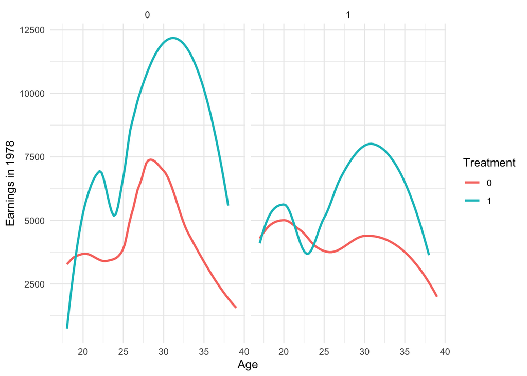

```r
fig <- df %>%
  filter(age < 40) %>%
  mutate(treat = factor(ifelse(treat==1,1,0))) %>%
  mutate(nodegree = factor(ifelse(nodegree==1,1,0)))
  # group_by(treat) %>%
  # summarize(meantreat = mean(re78))


ggplot(fig,
       aes(x = age,
           y = re78,
           color = treat)) +
  geom_smooth(se = F) +
  facet_wrap(~ nodegree) +
  labs(
       x = "Age",
       y = "Earnings in 1978",
       color = "Treatment") +
  theme_minimal()
```

## Propensity Score Trimming

Dehejia and Wahba (DW) re-examined the LaLonde (1986) study and argued that the failure of non-experimental estimators was largely driven by poor overlap between treated and control units rather than by regression or selection-on-observables methods per se. Using the same NSW treated group but carefully restricting attention to regions of common support, they showed that conditioning on a small set of pre-treatment covariates—especially lagged earnings—can substantially improve the credibility of non-experimental estimates.

A central insight of DW is that the Conditional Independence Assumption (CIA) is meaningful only when treated and control units are comparable in their covariates. When overlap is weak, regression or matching methods rely heavily on extrapolation, making estimates sensitive to specification choices and sample restrictions. DW therefore emphasize overlap and covariate balance as prerequisites for credible CIA-based estimation, rather than complex functional forms or aggressive trimming rules.

The CPS data contains a variable called `pscore`, which is the predicted probability of treatment from a logistic regression of `treat` on demographics (`age`, `education`, `black`, `hispanic`, `married`, `nodegree`), interactions between `education` and `black`, and quadratic terms in pre-treatment earnings (`re74` and `re75`). This variable can be used to assess overlap between treated and control units.

```r
dw <- df02 %>%
  filter((df02$pscore > .10) & (df02$pscore < .90))
```

```r
# models
model_dw <- list(
  "1. No controls" = lm(re78 ~ treat, data = dw),
  "2. Demographic controls " = lm(re78 ~ treat + age + education + black + hispanic + married + nodegree, data = dw),
  "3. Full model " = lm(re78 ~ treat + age + education + black + hispanic + married + nodegree + re74 + re75, data = dw)
)

# table
modelsummary(model_dw,
             vcov = "HC1",
             stars = T,
             gof_omit = "[^R2|R2 Adj.|Num.Obs]")
```

|  | 1. No controls | 2. Demographic controls | 3. Full model |
| --- | --- | --- | --- |
| (Intercept) | 5651.685*** | 1790.728 | 1822.829 |
|  | (403.944) | (3512.472) | (3420.461) |
| treat | 540.603 | 772.238 | 1439.946+ |
|  | (771.398) | (801.858) | (808.373) |
| age |  | -4.138 | -26.821 |
|  |  | (41.726) | (39.833) |
| education |  | 433.424+ | 422.978* |
|  |  | (221.999) | (211.790) |
| black |  | -880.651 | -1693.470 |
|  |  | (1065.875) | (1074.510) |
| married |  | 572.426 | 238.040 |
|  |  | (1099.883) | (1013.550) |
| nodegree |  | 56.620 | 343.749 |
|  |  | (1188.026) | (1152.276) |
| re74 |  |  | 0.133 |
|  |  |  | (0.120) |
| re75 |  |  | 0.371* |
|  |  |  | (0.150) |
| Num.Obs. | 403 | 403 | 403 |
| R2 | 0.001 | 0.023 | 0.065 |
| R2 Adj. | -0.001 | 0.008 | 0.046 |

+ p < 0.1, * p < 0.05, ** p < 0.01, *** p < 0.001

1. Re-estimate the regression table from Part 2, Question 3 using only the trimmed CPS sample. Compare your results to the untrimmed estimates.

   Restricting the sample gives us better overlap, therefore reducing interactions between variables and treat.